# vad_revised

### Snips VAD Challenge

**Halil Erdoğan**

*Note: I have used some randomness to create dataset. So that, result can differs.*

I will use 2 different method to create VAD.

- Heavily simplified version of CNN architecture with MFCC features which is based on [this paper.](https://ieeexplore.ieee.org/stamp/stamp.jsp?tp=&arnumber=8278160)
- Pitch estimation which is based on [CREPE library.](https://github.com/marl/crepe)

Before these, we need to create our dataset.

## Create Dataset

We need to download speech and noise files. I will use

- Snips Validation Dataset for Speech
- [ESC-50 for Noise](https://github.com/karoldvl/ESC-50)
  - **For Speech:** Also, we can use different corpus like [AMI Corpus](http://groups.inf.ed.ac.uk/ami/corpus/), however, with limited resources, I should choose small dataset. So I choose Snips Validation Dataset.
  - **For Noise:** This dataset includes many different types of noise. So that, our model can be more robust according to very few types of noise.

```python
!wget https://s3.amazonaws.com/snips/challenge/vad_data.tar.gz
!wget https://github.com/karoldvl/ESC-50/archive/master.zip
```

```
--2018-09-02 12:57:05--  https://s3.amazonaws.com/snips/challenge/vad_data.tar.gz
Resolving s3.amazonaws.com (s3.amazonaws.com)... 52.216.161.253
Connecting to s3.amazonaws.com (s3.amazonaws.com)|52.216.161.253|:443... connected.
HTTP request sent, awaiting response... 200 OK
Length: 307521331 (293M) [application/x-gzip]
Saving to: 'vad_data.tar.gz'

vad_data.tar.gz     100%[===================>] 293.27M  2.11MB/s    in 2m 5s

2018-09-02 12:59:11 (2.34 MB/s) - 'vad_data.tar.gz' saved [307521331/307521331]

--2018-09-02 12:59:11--  https://github.com/karoldvl/ESC-50/archive/master.zip
Resolving github.com (github.com)... 192.30.253.113, 192.30.253.112
Connecting to github.com (github.com)|192.30.253.113|:443... connected.
HTTP request sent, awaiting response... 302 Found
Location: https://codeload.github.com/karoldvl/ESC-50/zip/master [following]
--2018-09-02 12:59:12--  https://codeload.github.com/karoldvl/ESC-50/zip/master
Resolving codeload.github.com (codeload.github.com)... 192.30.253.120, 192.30.253.121
Connecting to codeload.github.com (codeload.github.com)|192.30.253.120|:443... connected.
HTTP request sent, awaiting response... 200 OK
Length: unspecified [application/zip]
Saving to: 'master.zip'

master.zip              [               <=>  ] 615.78M  2.78MB/s    in 4m 3s

2018-09-02 13:03:16 (2.53 MB/s) - 'master.zip' saved [645693466]
```

```python
# Uncompress files.

!tar xzf vad_data.tar.gz

import zipfile

with zipfile.ZipFile("master.zip","r") as zip_noise:
    zip_noise.extractall(".")

!mkdir outputs_audio # to store combination of noise and speech files.
!mkdir outputs_txt
```

- I will use the speech from Snips Validation set and noise from ESC-50 . Firstly, I want to create noisy audio file which includes speech and non-speech segments. To create non-speech segment, I will add silent segment to between of two segment if their difference is bigger than determined threshold.

```python
from pydub import AudioSegment
import json
import IPython.display as ipd
import numpy as np
import matplotlib.pyplot as pp
import math
import glob, os

def create_single_entry(speech_file, noise_file, threshold,
                       noise_supression):
    """With this function, we can create a wav file which is noisy and
    it includes both speech and non-speech segments. Also, these informations
    will be saved into txt file."""

    """Arguments:
    speech_file: Which speech file will be used
    noise_file: Which noise file will be used
    threshold: if difference between two consecutive segment is bigger than
        threshold value, we will add more silence (non-speech segment)
    noise_supression: how many DB, we will supress noise"""

    speech_filename=speech_file.split('/')[-1].split('.')[0]
    noise_filename=noise_file.split('/')[-1].split('.')[0]

    # Read the wav file
    song = AudioSegment.from_wav(speech_file)

    # Read the segments from json file and create array to store
    # end times and start times

    with open(speech_file[:-3] + 'json') as f:
        data = json.load(f)

    length = len(data["speech_segments"])

    start_time_array = []
    end_time_array = []

    for ix in range(0, length):
        start_time = (data["speech_segments"][ix]["start_time"])
        end_time = (data["speech_segments"][ix]["end_time"])
        start_time_array.append(start_time)
        end_time_array.append(end_time)

    # Add more silence to between of two segments which has silent part
    # that is bigger than our threshold. Also create the txt file to store
    # speech and non-speech segments' times.

    output = AudioSegment.empty() # to hold output audio segment

    f = open("./outputs_txt/" + speech_filename + "_" + noise_filename + ".txt", "w")

    prev_end_time = 0

    times_array = np.vstack((end_time_array[:-1],start_time_array[1:]))


    difference_between_segments = np.diff(times_array, axis=0)
    difference_between_segments = np.squeeze(difference_between_segments)

    total_silence_duration = 0
    offset = start_time_array[0]

    for ix_diff in range(0, len(difference_between_segments)):

        if (difference_between_segments[ix_diff] > threshold):
            silence_duration = np.random.randint(1300, high=2100)

            random_silence = AudioSegment.silent(duration=silence_duration, frame_rate = 16000)

            start_time = start_time_array[ix_diff]
            end_time = end_time_array[ix_diff]

            output += (song[int(start_time*1000):int(end_time*1000)] + random_silence)

            f.write('Speech: ' + str(total_silence_duration + int((start_time-offset)*1000)) +
                " " + str(total_silence_duration + int((end_time-offset)*1000)) + "\n")
            f.write('Noise: ' + str(total_silence_duration + int((end_time-offset)*1000)) +
                    " " + str(total_silence_duration + int((end_time-offset)*1000) + silence_duration) + "\n")

            total_silence_duration += silence_duration

        else:
            start_time = start_time_array[ix_diff]
            end_time = end_time_array[ix_diff]
            output += (song[int(start_time*1000):int(end_time*1000)])
            f.write('Speech: ' + str(total_silence_duration + int((start_time-offset)*1000)) +
                    " " + str(total_silence_duration + int((end_time-offset)*1000)) + "\n")

        offset += difference_between_segments[ix_diff]

    f.close()

    # Add noise to whole file

    noise = AudioSegment.from_wav(noise_file)
    noise = noise - noise_supression

    played_together = output.overlay(noise, loop=True)
    played_together = played_together.set_frame_rate(16000) # https://github.com/jiaaro/pydub/issues/232

    # Save the file as wav

    file_handle = played_together.export("./outputs_audio/" + speech_filename + "_" +
                                         noise_filename + ".wav", format="wav")
```

Now, we can test this function.

```python
create_single_entry("./vad_data/125-121342-0019.wav",
                    "./ESC-50-master/audio/1-27166-A-35.wav",
                    threshold=0.05,
                    noise_supression=6)

ipd.Audio("./outputs_audio/125-121342-0019_1-27166-A-35.wav")
```

[interactive chart not shown]

Our function works for one speech and one noise. Now, we need to create all dataset.

```python
root_dir_speech = glob.glob(os.path.join("./vad_data/", '*wav'))

root_dir_noise = glob.glob(os.path.join('./ESC-50-master/audio/', '*wav'))
```

```python
print ('How many speech: ', len(root_dir_speech))
print ('How many noise: ', len(root_dir_noise))
```

```
How many speech:  957
How many noise:  2000
```

Before the creation of dataset, I want to check speech datas.

```python
array_for_length = []

def investigate_folder(folder):

    for file in folder:

        filename=file.split('/')[-1].split('.')[0]

        # Read the wav file
        audio = AudioSegment.from_wav(file)

        # Learn the length of audio as a milisecond version
        length = len(audio)
        # Store the length in array
        array_for_length.append(length)

    return array_for_length
```

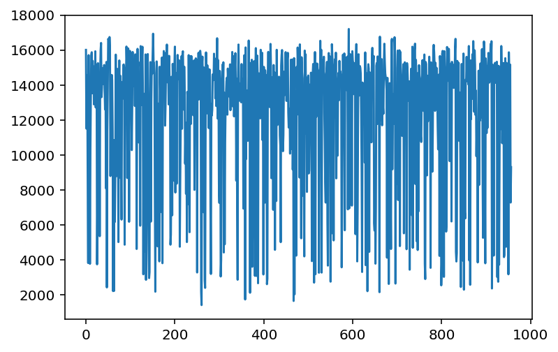

```python
%config InlineBackend.figure_format = 'retina'

length_of_speechs = investigate_folder(root_dir_speech)

pp.plot(length_of_speechs)
```

We can remove the file which is shorter than 6 seconds.

```python
def remove_short_speech_files(folder, threshold):
    total_num = 0
    for file in folder:

        filename=file.split('/')[-1].split('.')[0]

        # Read the wav file
        audio = AudioSegment.from_wav(file)

        # Learn the length of audio as a milisecond version
        length = len(audio)

        if (length<threshold):

            os.remove(file)
            total_num += 1

            # print (filename, " has been deleted: ", length, " milisecond.")

    print (total_num, "files has been deleted.")
```

```python
remove_short_speech_files(root_dir_speech, 6000)
```

```
113 files has been deleted.
```

Now, we can create our dataset.

```python
def create_dataset(speech_folder, noise_folder, how_many_speech,
                   how_many_noise, threshold,
                  noise_supression):
    """This function takes speech folder and noise folder and create
    new file via combination of these files from this folder according to
    following arguments."""

    """Arguments:
    speech folder: which folder includes wav and json for speech files
    noise folder: which folder includes wav file for noise
    how_many_speech: How many speech file will be used for dataset creation
    how_many_noise: we will create multiple files with one speech
        and more than one noise
    threshold: if difference between two consecutive segment is bigger than
    threshold value, we will add more silence (non-speech segment)
    noise_supression: how many DB, we will supress noise"""


    for ix in range(how_many_speech):
        speech_file = speech_folder[ix]

        # numpy.random.randint(low, high=None, size=None, dtype='l')

        which_noise_files_ix = np.random.randint(0, 2000, how_many_noise)

        for single_noise_file_ix in which_noise_files_ix:

            noise_file = noise_folder[single_noise_file_ix]

            create_single_entry(speech_file, noise_file, threshold,
                               noise_supression)
```

```python
root_dir_speech = glob.glob(os.path.join("./vad_data/", '*wav'))

root_dir_noise = glob.glob(os.path.join('./ESC-50-master/audio/', '*wav'))
```

```python
create_dataset(root_dir_speech, root_dir_noise,
               how_many_speech=len(root_dir_speech),
               how_many_noise=2,
               threshold=0.03,
               noise_supression=6)
```

# Deep Learning Architectures

### CNN which is based on MFCC feature.

- Create MFCC feature array.

```python
!mkdir mfcc_storage # to store mfcc files.
```

```python
f = open("featureplan.txt", "w")
f.write("mels: MelSpectrum blockSize=400 stepSize=160")
f.close()
```

```python
import warnings
warnings.filterwarnings("ignore", message="numpy.dtype size changed")

from numpy import genfromtxt
import numpy as np
import os
import glob
import math
import sys

def create_numpy_for_audio(audio_file, featureplan, sr=16000):
    """This function is based on YAAFE. It will return 2D Array which is features of audio file.
    Also it will save the numpy array.

    Its arguments:
    featureplan: Text file which introduce which features will be extracted.
    audio_file: Path of audio file, it can be wav, mp3, ogg etc.
    sr: Sample rate for audio file. Default as 16000."""

    !yaafe -c $featureplan -r $sr $audio_file -p Precision=6 -p Metadata=False -n
    filename = (audio_file.split("/")[-1]).split(".")[0]

    my_data = genfromtxt(audio_file + ".mels.csv", delimiter=',')

    os.remove(audio_file + ".mels.csv")
    np.save('./mfcc_storage/' + filename, my_data)

    return my_data
```

This function saves the feature extraction of single audio file. We need to apply this function to whole dataset.

```python
def create_dataset_mfcc(root_dir, featureplan):
    """With this function, we will store the each file's mfcc feature extraction
    as a numpy array.
    Arguments:
    root_dir: which folder includes the audio files.
    featureplan: Which txt will be used to express features"""

    for file in root_dir:
        create_numpy_for_audio(file, featureplan=featureplan)
```

```python
root_dir_out_speech = glob.glob(os.path.join("./outputs_audio/", '*wav'))
```

```python
"""Note: I have executed this code before html conversion, however, it gives long output. So that,
now I just convert to a comment."""

# create_dataset_mfcc(root_dir_out_speech, "featureplan.txt")
```

```
'Note: I have executed this code before html conversion, however, it gives long output. So that, \nnow I just convert to a comment.'
```

Also, we have txt file which holds the information for speech and non-speech segments. We need to transform these informations to suitable formats.

```python
def create_output_mfcc(filename, shape, win_len=25, hop=10):
    """With this function, we will create output for
    a file for mfcc feature extraction type of input."""

    """Arguments:
    filename: Which txt file include the information
    for speech and non-speech part.
    shape: This info is based on mfcc input's shape."""

    output_array = np.zeros(shape)

    with open(filename) as f:
        content = f.readlines()

    content = [x.strip() for x in content]

    for i in content:
        type_of, start, end = i.split(" ")
        if (type_of == 'Speech:'):
            which_start_hop = (int(start) - win_len) / hop
            which_end_hop = (int(end) - win_len) / hop

            start_location = math.ceil(which_start_hop)

            if (start_location<0): # to get rid confusion at first frame
                start_location=0

            end_location = math.ceil(which_end_hop)

            output_array[start_location:end_location] = 1.0
    return output_array
```

Now, we can create our Deep Learning Architecture. (It is heavily simplifed version of [the article's architecture.](https://ieeexplore.ieee.org/stamp/stamp.jsp?tp=&arnumber=8278160))

```python
import warnings
warnings.filterwarnings("ignore", message="numpy.dtype size changed")
import keras

from keras import layers
from keras import models
from keras import optimizers
from keras.models import Model
import tensorflow as tf
from keras.utils.generic_utils import get_custom_objects
from keras.models import load_model
import time

frame_shape = (240, 40, 1)

input_frame = keras.Input(frame_shape, name='main_input')

conv1 = layers.Conv2D(40, kernel_size=(5, 5), strides=(1, 1), padding="same",
                     kernel_initializer="TruncatedNormal",
                     bias_initializer="TruncatedNormal")(input_frame)
conv1 = layers.LeakyReLU()(conv1)
conv1_BN = layers.BatchNormalization()(conv1)


conv2 = layers.Conv2D(20, kernel_size=(5, 5), strides=(1, 1), padding="same",
                     kernel_initializer="TruncatedNormal",
                     bias_initializer="TruncatedNormal")(conv1_BN)
conv2 = layers.LeakyReLU()(conv2)
conv2_BN = layers.BatchNormalization()(conv2)


conv3 = layers.Conv2D(10, kernel_size=(5, 5), strides=(1, 1), padding="same",
                     kernel_initializer="TruncatedNormal",
                     bias_initializer="TruncatedNormal")(conv2_BN)
conv3 = layers.LeakyReLU()(conv3)
conv3_BN = layers.BatchNormalization()(conv3)


xx = layers.TimeDistributed(layers.Flatten())(conv3_BN)


tdistributed_1 = layers.TimeDistributed(layers.Dense(100, kernel_initializer='TruncatedNormal',
                bias_initializer='TruncatedNormal'))(xx)
tdistributed_1 = layers.LeakyReLU()(tdistributed_1)
tdistributed_1_BN = layers.BatchNormalization()(tdistributed_1)
tdistributed_1_drop = layers.Dropout(0.5)(tdistributed_1_BN)

tdistributed_2 = layers.TimeDistributed(layers.Dense(1, activation='sigmoid',
                                            kernel_initializer='TruncatedNormal',
                                            bias_initializer='TruncatedNormal'))(tdistributed_1_drop)

model = Model(input_frame, tdistributed_2)

Adagrad = keras.optimizers.Adagrad(lr=0.01, epsilon=None, decay=0.0)

Nadam = keras.optimizers.Nadam(lr=0.001, beta_1=0.9, beta_2=0.999, epsilon=0.00001, schedule_decay=0.0002)

model.compile(loss='binary_crossentropy', optimizer="Nadam", metrics=['accuracy'])
```

```python
model.summary()
```

```
_________________________________________________________________
Layer (type)                 Output Shape              Param #
=================================================================
main_input (InputLayer)      (None, 240, 40, 1)        0
_________________________________________________________________
conv2d_7 (Conv2D)            (None, 240, 40, 40)       1040
_________________________________________________________________
leaky_re_lu_9 (LeakyReLU)    (None, 240, 40, 40)       0
_________________________________________________________________
batch_normalization_9 (Batch (None, 240, 40, 40)       160
_________________________________________________________________
conv2d_8 (Conv2D)            (None, 240, 40, 20)       20020
_________________________________________________________________
leaky_re_lu_10 (LeakyReLU)   (None, 240, 40, 20)       0
_________________________________________________________________
batch_normalization_10 (Batc (None, 240, 40, 20)       80
_________________________________________________________________
conv2d_9 (Conv2D)            (None, 240, 40, 10)       5010
_________________________________________________________________
leaky_re_lu_11 (LeakyReLU)   (None, 240, 40, 10)       0
_________________________________________________________________
batch_normalization_11 (Batc (None, 240, 40, 10)       40
_________________________________________________________________
time_distributed_7 (TimeDist (None, 240, 400)          0
_________________________________________________________________
time_distributed_8 (TimeDist (None, 240, 100)          40100
_________________________________________________________________
leaky_re_lu_12 (LeakyReLU)   (None, 240, 100)          0
_________________________________________________________________
batch_normalization_12 (Batc (None, 240, 100)          400
_________________________________________________________________
dropout_3 (Dropout)          (None, 240, 100)          0
_________________________________________________________________
time_distributed_9 (TimeDist (None, 240, 1)            101
=================================================================
Total params: 66,951
Trainable params: 66,611
Non-trainable params: 340
_________________________________________________________________
```

Now, we need to train this system. Before the train, we need to define function to upload our datas.

```python
def prepare_data_to_train(root_dir_mfcc, from_ix, to_ix):

    """With this function, train datas will be transformed to
    suitable format for DL architecture.

    Arguments:
    root_dir_mfcc: Where mfcc numpy array is stored.
    from_ix: Index for first file.
    to_ix: Index for last file."""

    input_array = []
    output = []

    for ix in range(from_ix, to_ix):
        feature_vector = np.load(root_dir_mfcc[ix])
        feature_array = np.ravel(feature_vector)
        input_array.extend(feature_array)

        filename_txt = (str(root_dir_mfcc[ix]).split("/")[-1])[:-3] + "txt"
        output_array = create_output_mfcc("./outputs_txt/" + filename_txt,
                                          shape=feature_vector.shape[0])

        # print ('Input File: ', root_dir_speech[ix])
        # print ('Output File: ', filename_txt)


        output.extend(output_array)

    input_array = np.reshape(input_array, (-1, 40))

    output_array = np.asarray(output)
    output_array = np.expand_dims(output_array, axis=1)

    return (input_array, output_array)
```

```python
root_dir_out_mfcc =  glob.glob(os.path.join("./mfcc_storage/", '*npy'))
root_dir_speech = glob.glob(os.path.join("./vad_data/", '*wav'))
root_dir_noise = glob.glob(os.path.join('./ESC-50-master/audio/', '*wav'))
```

```python
input_array, output_array = prepare_data_to_train (root_dir_out_mfcc, 0, 1200)

max_len = 240 # how many frame will be taken
step = 240 # step size.

input_array_specified = []
output_array_specified = []

for i in range (0, input_array.shape[0]-max_len, step):
    single_input_specified = (input_array[i:i+max_len,:])
    single_output_specified = (output_array[i:i+max_len,:])

    input_array_specified.append(single_input_specified)
    output_array_specified.append(single_output_specified)

output_array_specified = np.asarray(output_array_specified)
input_array_specified = np.asarray(input_array_specified)

input_array_specified = np.expand_dims(input_array_specified, axis=4)
history = model.fit(input_array_specified, output_array_specified,
                   epochs=5,
                   batch_size=4,
                   validation_split=0.2,
                   shuffle=False)

model.save_weights('bilstm_weights_2DCNN.h5')
```

```
Train on 7755 samples, validate on 1939 samples
```

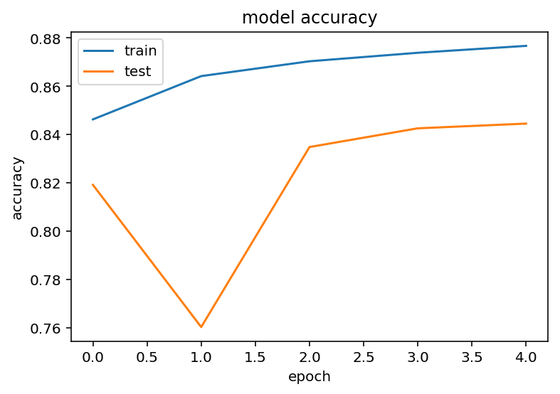

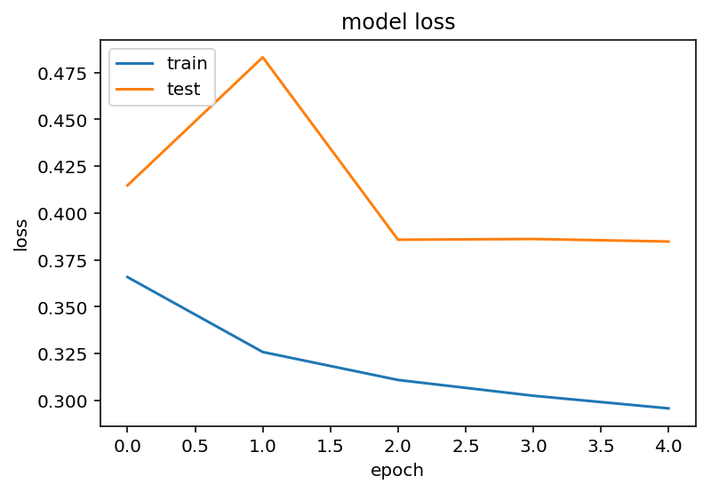

```python
# summarize history for accuracy
pp.plot(history.history['acc'])
pp.plot(history.history['val_acc'])
pp.title('model accuracy')
pp.ylabel('accuracy')
pp.xlabel('epoch')
pp.legend(['train', 'test'], loc='upper left')
pp.show()
# summarize history for loss
pp.plot(history.history['loss'])
pp.plot(history.history['val_loss'])
pp.title('model loss')
pp.ylabel('loss')
pp.xlabel('epoch')
pp.legend(['train', 'test'], loc='upper left')
pp.show()
```

Now, we need to evaluate our method. We will use our test data. Before that, we need post-processing algorithms.

```python
def minimum_speech_time(prediction_array, how_many_frame, threshold_mean):
    """It takes prediction array(it contains 0 and 1. 0 means that
    non-speech, 1 means that speech.) As we know, when people speaks, it takes
    at least some frame. So, if we see just 1 without determined number of neighboor 1,
    we need to discard it.

    Arguments:
    prediction_array: Which array will be considered.
    how_many_frame: Minumum speech duration as frame number.
    threshold_mean: If segment's mean is lower than this value, we
        will consider as non-speech segment."""

    for ix in range(0, len(prediction_array-how_many_frame)):
        prediction_segment = prediction_array[ix:ix+how_many_frame]
        if (np.mean(prediction_segment) < threshold_mean):
            prediction_array[ix] = 0

    return prediction_array
```

```python
def hangover(prediction_array, threshold_hangover):
    """We can use a hangover time, such that after a speech segment
    we keep the label as speech for a while until we are sure that
    speech has ended. (resource:
    https://mycourses.aalto.fi/pluginfile.php/146209/mod_resource/content/1/slides_07_vad.pdf)

    Arguments:
    prediction_array: Which array will be evaluated.
    threshold_hangover: If two speech segment difference less than this value, we
        will consider the between segments as a speech segment."""

    speech_segment_locations = np.where(prediction_array == 1)

    for ix in range(0, len(speech_segment_locations)-1):
        if (speech_segment_locations[ix+1]+threshold_hangover < speech_segment_locations[ix]):
            prediction_array[speech_segment_locations[ix]:speech_segment_locations[ix+1]+1] = 1

    return prediction_array
```

```python
def smoothing(feature_vector,
             dl_model):

    prediction_vector = []
    prediction_array_average = []

    ix_frame = 0

    while ((ix_frame+239)<feature_vector.shape[0]):

            prediction = dl_model.predict(np.expand_dims(feature_vector[ix_frame:ix_frame+240], axis=0))
            prediction = prediction.squeeze(axis=2)
            prediction = prediction.squeeze(axis=0)

            prediction_vector.append(prediction)

            ix_frame += 60

    prediction_vector = np.asarray(prediction_vector)
    prediction_array = np.ravel(prediction_vector)

    ix_frame_pred = 0

    total_prediction = len(prediction_array)

    print (total_prediction)

    prediction_array_average[0:60] = prediction_array[0:200]
    prediction_array_average[60:120] = (prediction_array[200:400]+prediction_array[800:1000]) * 0.5
    prediction_array_average[120:180] = (prediction_array[400:600]+prediction_array[1000:1200]+
                                         prediction_array[1600:1800]) * 0.33

    ix_frame = 180
    count = 0

    while ((ix_frame+238)<total_prediction):

        next_frame = ix_frame + (count * 180)
        try:
            prediction_array_average[ix_frame:ix_frame+60] = (prediction_array[next_frame:next_frame+60]+
                                                              prediction_array[next_frame+180:next_frame+240]+
                                                              prediction_array[next_frame+360:next_frame+420]+
                                                              prediction_array[next_frame+540:next_frame+600]) * 0.25
        except:
            pass
        ix_frame += 60
        count += 1

    prediction_array = np.asarray(prediction_array_average)

    return prediction_array
```

```python
def metrics(ground_truth,
           prediction,
           show_print):

    """Metrics for evaluation. It will print the some metrics.

    Arguments:
    ground_truth: Ground trurh(reference) vector.
    prediction: Prediction vector which is created by
        DL model.
    show_print: If it is true, it will print the whole outputs."""

    num_speech_speech = 0
    num_speech_noise = 0
    num_noise_noise = 0
    num_noise_speech = 0

    for ix in range(0, len(ground_truth)):
        if (ground_truth[ix]==1):
            if (prediction[ix]==1):
                num_speech_speech += 1
            else:
                num_speech_noise += 1
        else:
            if (prediction[ix]==1):
                num_noise_speech += 1
            else:
                num_noise_noise += 1

    if (show_print):
        print ('Truth is Speech, Prediction is Speech: ', num_speech_speech,
              '\nTruth is Speech, Prediction is Noise: ', num_speech_noise,
              '\nTruth is Noise, Prediction is Speech: ', num_noise_speech,
              '\nTruth is Noise, Prediction is Noise: ', num_noise_noise)

    return (num_speech_speech,
           num_speech_noise,
           num_noise_speech,
           num_noise_noise)
```

```python
def evaluate_mfcc(filename, dl_model, smooth, threshold,
                 show_graph,
                 show_print):

    """We evaluate 1 as speech, 0 as non-speech. With this function,
    we can see evaluation of CNN based Deep Learning model's performance.

    Arguments:
    filename: Which file will be considered.
    dl_model: Which Deep Learning model will be used.
    smooth: Will system use smooth prediction.
    threshold: If prediction is bigger than this value,
        we will consider that segment as a speech. If not,
        we will consider as as non-speech.
    show_graph: If it is true, we can see the graph to understand
        evaluation.
    show_print: If it is true, it will print the whole outputs."""

    feature_vector = np.load(filename)
    feature_vector = np.expand_dims(feature_vector, axis=2)

    filename_txt = (filename.split("/")[-1])[:-3] + "txt"
    ground_truth = create_output_mfcc("./outputs_txt/" + filename_txt,
                                      shape=feature_vector.shape[0])

    prediction_vector = []

    ix_frame = 0

    if (smooth):

        prediction_array = smoothing(feature_vector,
                                    dl_model)

    else:

        while (ix_frame+239<feature_vector.shape[0]):
            split_feature_vector = feature_vector[ix_frame:ix_frame+240]
            prediction = dl_model.predict(np.expand_dims(split_feature_vector,axis=0))
            prediction = prediction.squeeze(axis=2)
            prediction = prediction.squeeze(axis=0)

            prediction_vector.append(prediction)
            ix_frame += 240

        prediction_vector = np.asarray(prediction_vector)

        prediction_array = np.ravel(prediction_vector)

    prediction=[]

    for ix in range(len(prediction_array)):
        if (prediction_array[ix] > threshold):
            prediction.append(1)
        else:
            prediction.append(0)

    prediction = np.asarray(prediction)

    ground_truth = ground_truth[0:len(prediction)]


    if (show_print):
        print ('Metrics without post-processing')
    num_speech_speech, num_speech_noise, num_noise_speech, num_noise_noise = metrics(ground_truth,
                                                                                     prediction,
                                                                                     show_print=show_print)
    if (show_print):
        print ('Metrics with Minimum Speech Time')
    num_speech_speech_mst, num_speech_noise_mst, num_noise_speech_mst, num_noise_noise_mst = metrics(ground_truth,
                                                                         minimum_speech_time(prediction, 30, 0.5),
                                                                         show_print=show_print)

    if (show_print):
        print ('Metrics with Hangover')
    num_speech_speech_han, num_speech_noise_han, num_noise_speech_han, num_noise_noise_han = metrics(ground_truth,
                                                                                              hangover(prediction, 3),
                                                                                              show_print=show_print)

    if (show_graph):

        pp.plot(ground_truth)
        pp.plot(prediction, color='r')
        pp.plot(minimum_speech_time(prediction, 30, 0.5))
        pp.plot(hangover(prediction,
                         3))
        pp.legend(['ground_truth', 'prediction',
                  'prediction with MST',
                  'prediction with Hangover'], loc='upper left')

        ipd.Audio("./outputs_audio/" + filename_txt[:-3] + "wav")

    return (num_speech_speech,
           num_speech_noise,
           num_noise_speech,
           num_noise_noise)
```

```
Metrics without post-processing
Truth is Speech, Prediction is Speech:  995
Truth is Speech, Prediction is Noise:  68
Truth is Noise, Prediction is Speech:  11
Truth is Noise, Prediction is Noise:  846
Metrics with Minimum Speech Time
Truth is Speech, Prediction is Speech:  927
Truth is Speech, Prediction is Noise:  136
Truth is Noise, Prediction is Speech:  4
Truth is Noise, Prediction is Noise:  853
Metrics with Hangover
Truth is Speech, Prediction is Speech:  927
Truth is Speech, Prediction is Noise:  136
Truth is Noise, Prediction is Speech:  4
Truth is Noise, Prediction is Noise:  853
```

```
(995, 68, 11, 846)
```

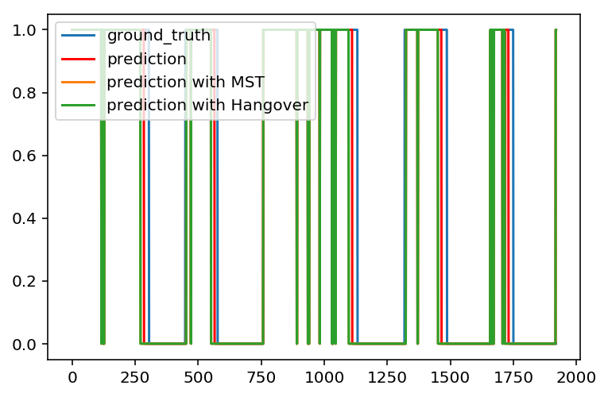

```python
# Lets look the evaluation for one test data.

evaluate_mfcc(root_dir_out_mfcc[200],
             dl_model=model,
             smooth=False,
             threshold=0.3,
             show_graph=True,
             show_print=True)
```

**There is strange bug. I can not figure out why MST and Hangover give exactly same results. This probably comes from Jupyter Notebook's hidden state (Resource: https://docs.google.com/presentation/d/1n2RlMdmv1p25Xy5thJUhkKGvjtV-dkAIsUXP-AL4ffI/edit?usp=sharing) or my error.**

**So that, I will take the result without post-processing**

Now, we can look the result for all our **test** data.

```python
total_num_speech_speech = 0
total_num_speech_noise = 0
total_num_noise_speech = 0
total_num_noise_noise = 0

for file in root_dir_out_mfcc[1200:]:

    s_s , s_n, n_s, n_n = evaluate_mfcc(file,
             dl_model=model,
             smooth=False,
             threshold=0.54,
             show_graph=False,
             show_print=False)

    total_num_speech_speech += s_s
    total_num_speech_noise += s_n
    total_num_noise_speech += n_s
    total_num_noise_noise += n_n
```

With few epochs and few datas, our model get these results.

```python
print ("Ground Truth: Speech, Prediction: Speech ", total_num_speech_speech)
print ("Ground Truth: Speech, Prediction: Noise ",total_num_speech_noise)
print ("Ground Truth: Noise, Prediction: Speech ",total_num_noise_speech)
print ("Ground Truth: Noise, Prediction: Noise ",total_num_noise_noise)
```

```
Ground Truth: Speech, Prediction: Speech  384753
Ground Truth: Speech, Prediction: Noise  77588
Ground Truth: Noise, Prediction: Speech  54616
Ground Truth: Noise, Prediction: Noise  362403
```

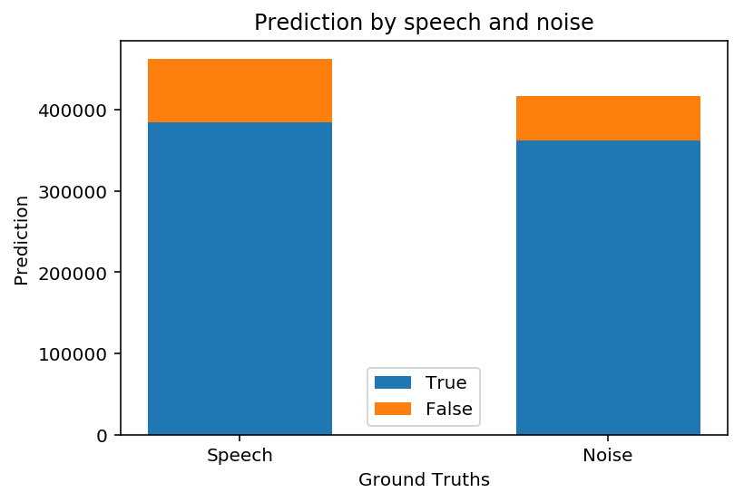

```python
N = 2
true = (total_num_speech_speech, total_num_noise_noise)
false = (total_num_speech_noise, total_num_noise_speech)
ind = np.arange(N)    # the x locations for the groups
width = 0.5       # the width of the bars: can also be len(x) sequence

p1 = pp.bar(ind, true, width)
p2 = pp.bar(ind, false, width, bottom=true)

pp.xlabel('Ground Truths')
pp.ylabel('Prediction')
pp.title('Prediction by speech and noise')
pp.xticks(ind, ('Speech', 'Noise'))
pp.legend((p1[0], p2[0]), ('True', 'False'))

pp.show()
```

### Pitch Estimation Based

I will use directly CREPE method. This method will be quick solution for the problem. Also, we can combine the outputs of this method as a feature of another deep learning method. However, at that time, I will use outputs of CREPE without deep learning.

```python
!mkdir crepe_storage
```

```python
import crepe
from scipy.io import wavfile

def create_numpy_crepe(file, viterbi, step_size):
    """With this function, we will store the each file's confidence and frequency outputs
    as a numpy array. These outputs will be created by CREPE.

    Arguments:
    root_dir: which folder includes the audio files.
    viterbi: If it is true, CREPE will apply viterbi algorithm.
    step_size: Which step size will be used."""

    sr, audio = wavfile.read(file)
    filename = file.split('/')[-1][:-4]
    print (filename)
    time, frequency, confidence, activation = crepe.predict(audio, sr,
                                                            viterbi=viterbi,
                                                            step_size=step_size)
    np.save('./crepe_storage/' + filename + '_frequency', frequency)
    np.save('./crepe_storage/' + filename + '_confidence', confidence)
```

```python
def create_dataset_crepe(root_dir, viterbi, step_size):
    """With this function, we will store the folder's confidence and frequency outputs
    as a numpy array. These outputs will be created by CREPE.

    Arguments:
    root_dir: which folder includes the audio files.
    viterbi: If it is true, CREPE will apply viterbi algorithm.
    step_size: Which step size will be used."""

    for file in root_dir:
        create_numpy_crepe(file, viterbi, step_size)
```

```python
create_dataset_crepe(root_dir_out_speech[300:315], viterbi=True, step_size=10)
```

```
1898-145715-0046_3-119120-E-48
```

```
1263-138246-0035_3-102583-C-49
1898-145715-0016_2-28314-B-12
1088-134315-0027_2-98676-A-24
```

```
1502-122615-0035_5-250629-A-37
1246-135815-0010_2-117615-B-48
19-227-0046_5-195517-A-7
1034-121119-0075_4-234879-A-6
118-47824-0054_4-171706-A-23
1116-132847-0010_4-160036-A-33
1867-148436-0042_1-29561-A-10
118-47824-0031_4-168155-A-15
1624-142933-0037_4-197871-A-15
1455-134435-0021_5-170338-B-41
1263-139804-0010_4-172734-A-36
```

We need to npy file for frequency and confidence via crepe, however, it takes much time on my CPU. So that, I just used 15 files to evaluate the method.

Lets look some examples.

```python
def create_output_crepe(filename):
    """With this function, we will create output for
    a file for crepe type of input."""

    """Arguments:
    filename: Which txt file include the information
        for speech and non-speech part."""
    with open(filename) as f:
        content = f.readlines()

    content = [x.strip() for x in content]

    output_array = np.zeros(int(int(content[-1].split(" ")[-1])/10))
    for i in content:
        type_of, start, end = i.split(" ")
        if (type_of == 'Speech:'):
            output_array[int(int(start)/10):int(int(end)/10)] = 1.0
    return output_array
```

```python
root_dir_out = glob.glob(os.path.join('./crepe_storage/', '*confidence.npy'))
random_file = root_dir_out[3]

filename = (random_file.split("/")[-1])[:-15]

ground_truth = create_output_crepe("./outputs_txt/" + filename + ".txt")
confidence = np.load(random_file)
frequency = np.load('./crepe_storage/' + filename + "_frequency.npy")

ipd.Audio("./outputs_audio/" + filename + ".wav")
```

[interactive chart not shown]

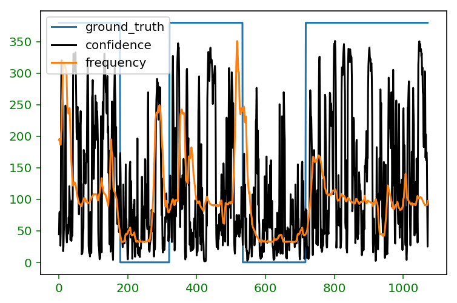

```python
pp.tick_params(axis='x', colors='green')
pp.tick_params(axis='y', colors='green')

pp.plot(ground_truth*380)
pp.plot(confidence*380, color='k')
pp.plot(frequency)
pp.legend(['ground_truth', 'confidence',
            'frequency'], loc='upper left')
# pp.plot(create_output_crepe(rastgele_txt)*400, color='cyan')
# pp.plot(create_prediction(confidence, 30, 0.3)*500, color='pink')
```

With CREPE, I can use 2 different outputs. One is confidence, other one is frequency. According to my inital test, frequency is not so suitable with direct prediction. However, with more investigation, we can figure out the way to use frequency.

- Confidence: It represent the confidence of the model to predict pitch estimation of the frame. If speech is present, confidence should be high. If non-speech is present, confidence should be low. Therefore, I will directly use confidence vector to understand speech and non-speech segment.

**It is light-weight solution and we will see the result with the following steps.**

```python
"""Idea: Speech sounds can be efficiently modelled by linear prediction.
Source: https://mycourses.aalto.fi/pluginfile.php/146209/mod_resource/content/1/slides_07_vad.pdf"""

def create_prediction_conf(confidence, step, threshold):

    """It will create the prediction vector which is based
    on confidence vector.

    Arguments:
    confidence: Which confidence vector will be used.
    step: Step size of frames.
    threshold: Threshold to determine speech or non-speech
        segment. If confidence vector's step is bigger
        than this value, we will consider that segment(step)
        as a speech. If lower than this value,
        we will consider as a non-speech."""

    length_of_matrix = len(confidence)

    prediction_matrix = np.zeros(length_of_matrix)

    for ix in range(0, length_of_matrix-step):
        mean = np.mean(confidence[ix:ix+step])
        if (mean > threshold):
            prediction_matrix[ix:ix+step] = 1.0

    return prediction_matrix
```

```python
def evaluate_crepe(ground_truth,
                  prediction):

    """We evaluate 1 as speech, 0 as non-speech.
    With this function, we will learn the prediction is correct or not.

    Arguments:
    ground_truth: Ground Truth(reference) vector.
    prediction: Prediction vector."""

    num_speech = 0
    num_noise = 0

    num_speech_speech = 0
    num_speech_noise = 0
    num_noise_noise = 0
    num_noise_speech = 0

    for ix in range(0, len(ground_truth)):
        if (ground_truth[ix]==1):
            num_speech += 1
            if (prediction[ix]==1):
                num_speech_speech += 1
            else:
                num_speech_noise += 1
        else:
            num_noise += 1
            if (prediction[ix]==1):
                num_noise_speech += 1
            else:
                num_noise_noise += 1

    print ('Truth is Speech, Prediction is Speech: ', num_speech_speech,
          '\nTruth is Speech, Prediction is Noise: ', num_speech_noise,
          '\nTruth is Noise, Prediction is Speech: ', num_noise_speech,
          '\nTrurh is Noise, Prediction is Noise: ', num_noise_noise)
```

```python
# Lets evaluate the crepe.

root_dir_out_crepe = glob.glob(os.path.join("./crepe_storage/", '*confidence.npy'))

total_num_speech_speech = 0
total_num_speech_noise = 0
total_num_noise_speech = 0
total_num_noise_noise = 0

for file in root_dir_out_crepe:

    filename = (file.split("/")[-1])[:-15]

    print (filename)

    prediction_array = create_prediction_conf(confidence=np.load(file),
                                        step=10,
                                        threshold=0.4)

    try:
        s_s , s_n, n_s, n_n = evaluate_crepe(create_output_crepe("./outputs_txt/" + filename + ".txt"), prediction_array)
    except:
        pass

    total_num_speech_speech += s_s
    total_num_speech_noise += s_n
    total_num_noise_speech += n_s
    total_num_noise_noise += n_n
```

```
1246-135815-0010_2-117615-B-48
Truth is Speech, Prediction is Speech:  1194
Truth is Speech, Prediction is Noise:  137
Truth is Noise, Prediction is Speech:  0
Trurh is Noise, Prediction is Noise:  731
1502-122615-0035_5-250629-A-37
Truth is Speech, Prediction is Speech:  949
Truth is Speech, Prediction is Noise:  79
Truth is Noise, Prediction is Speech:  321
Trurh is Noise, Prediction is Noise:  498
19-227-0046_5-195517-A-7
Truth is Speech, Prediction is Speech:  932
Truth is Speech, Prediction is Noise:  79
Truth is Noise, Prediction is Speech:  366
Trurh is Noise, Prediction is Noise:  282
118-47824-0054_4-171706-A-23
Truth is Speech, Prediction is Speech:  503
Truth is Speech, Prediction is Noise:  243
Truth is Noise, Prediction is Speech:  51
Trurh is Noise, Prediction is Noise:  275
1034-121119-0075_4-234879-A-6
Truth is Speech, Prediction is Speech:  449
Truth is Speech, Prediction is Noise:  157
Truth is Noise, Prediction is Speech:  113
Trurh is Noise, Prediction is Noise:  441
118-47824-0031_4-168155-A-15
Truth is Speech, Prediction is Speech:  548
Truth is Speech, Prediction is Noise:  136
Truth is Noise, Prediction is Speech:  131
Trurh is Noise, Prediction is Noise:  630
1624-142933-0037_4-197871-A-15
Truth is Speech, Prediction is Speech:  1021
Truth is Speech, Prediction is Noise:  158
Truth is Noise, Prediction is Speech:  99
Trurh is Noise, Prediction is Noise:  1049
1263-138246-0035_3-102583-C-49
Truth is Speech, Prediction is Speech:  934
Truth is Speech, Prediction is Noise:  195
Truth is Noise, Prediction is Speech:  197
Trurh is Noise, Prediction is Noise:  790
```

[output cut: 20 more lines]

```
1116-132847-0010_4-160036-A-33
Truth is Speech, Prediction is Speech:  415
Truth is Speech, Prediction is Noise:  113
Truth is Noise, Prediction is Speech:  0
Trurh is Noise, Prediction is Noise:  313
1455-134435-0021_5-170338-B-41
Truth is Speech, Prediction is Speech:  628
Truth is Speech, Prediction is Noise:  85
Truth is Noise, Prediction is Speech:  533
Trurh is Noise, Prediction is Noise:  153
1867-148436-0042_1-29561-A-10
Truth is Speech, Prediction is Speech:  907
Truth is Speech, Prediction is Noise:  267
Truth is Noise, Prediction is Speech:  0
Trurh is Noise, Prediction is Noise:  1070
```

```python
print ("Ground Truth: Speech, Prediction: Speech ", total_num_speech_speech)
print ("Ground Truth: Speech, Prediction: Noise ",total_num_speech_noise)
print ("Ground Truth: Noise, Prediction: Speech ",total_num_noise_speech)
print ("Ground Truth: Noise, Prediction: Noise ",total_num_noise_noise)
```

```
Ground Truth: Speech, Prediction: Speech  12420
Ground Truth: Speech, Prediction: Noise  1665
Ground Truth: Noise, Prediction: Speech  30
Ground Truth: Noise, Prediction: Noise  14685
```

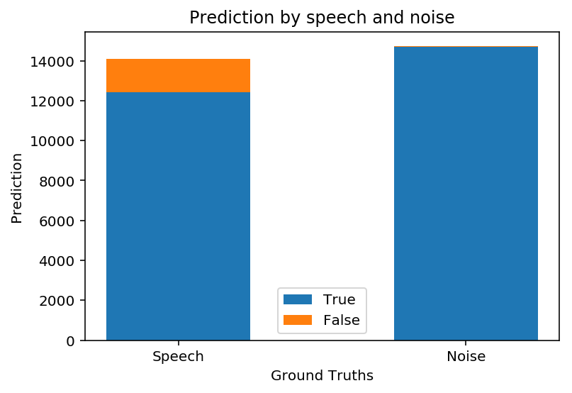

```python
N = 2
true = (total_num_speech_speech, total_num_noise_noise)
false = (total_num_speech_noise, total_num_noise_speech)
ind = np.arange(N)    # the x locations for the groups
width = 0.5       # the width of the bars: can also be len(x) sequence

p1 = pp.bar(ind, true, width)
p2 = pp.bar(ind, false, width, bottom=true)

pp.xlabel('Ground Truths')
pp.ylabel('Prediction')
pp.title('Prediction by speech and noise')
pp.xticks(ind, ('Speech', 'Noise'))
pp.legend((p1[0], p2[0]), ('True', 'False'))

pp.show()
```

### Conclusion

With limited resource and time, I tried two light-weight solution for Voice Activity Detection. Both of them can be used real-time with very small latency and so limited resource. Main advantage of these methods is provide good result with so limited memory and power consumption.

**If I have more time:**

- I can fine tune the hyperparamater of Post-Processing steps.
- I can modify Deep Learning architecture to get better result.
  - More depth CNN
  - Attention
  - Cyclic Learning Rate
  - Different Optimizers
  - Different Loss Functions
  - Temporal Convolutional Network
  - Hyperparameter optimization
  - CapsuleNet or NALU
- I can use more data to train my system and evaluate according to different noise type, different noise supression, male-female speech etc.
- I can use different features as an Input. For instance, energy, delta values etc. Especially [RNNoise](https://people.xiph.org/~jm/demo/rnnoise/)'s features can be used.
- I can combine CREPE's output with LSTM network.
- Combine with [tensorflow.js](https://js.tensorflow.org). Thus, we can use whole system in browser.